# Lab1B

Michiel Klaassen

14-2-2021

```r
set.seed(123)
vec_1 <- rnorm(10)
vec_2 <- as.integer(vec_1)
vec_3 <- c(rep(TRUE, 3), c(rep(FALSE, 4)), NA)
vec_4 <- as.numeric(vec_3)
vec_5 <- c("Marc", "Ronald", "Maarten")
```

# 1. Creating some vectors

1. What does set.seed(123) do? Check the documentation!
   - Set a seed which makes sure the random values are constant from that point on
2. What does the above as.integer() function do?
   - Cast all numbers to whole numbers, integers.
3. And as.numeric()?
   - Transform the logical values “TRUE” and “FALSE” to 1 and 0 respectively.
4. Check the contents of vec_2, vec_3 and vec_4

```r
vec_2
```

```
##  [1]  0  0  1  0  0  1  0 -1  0  0
```

```r
vec_3
```

```
## [1]  TRUE  TRUE  TRUE FALSE FALSE FALSE FALSE    NA
```

```r
vec_4
```

```
## [1]  1  1  1  0  0  0  0 NA
```

5. Determine the class() of vec_1 to vec_5

```r
class(vec_1)
```

```
## [1] "numeric"
```

```r
class(vec_2)
```

```
## [1] "integer"
```

```r
class(vec_3)
```

```
## [1] "logical"
```

```r
class(vec_4)
```

```
## [1] "numeric"
```

```r
class(vec_5)
```

```
## [1] "character"
```

6. What happens to the data type if we combine (using c() vec_1 en vec_2)? Why?
   - It casts the integer vector to a number vector. It uses coercion and decides automatically up the tree of types what it can best cast to.
   - If we run `vec_ptype2(vec_1, vec_2)` we see that it suggests `numeric(0)` because that is what it will cast to.

```r
vec_ptype2(vec_1, vec_2)
```

```
## numeric(0)
```

````
+ If we run ```vec_cast(vec_1, vec_2)``` it gives us an error that it can't convert doubles to integers due to loss of precision. Which is probably a hint why it gives us ```numeric(0)``` as suggestion: we won't lose any precision in either of the 2 vectors.
````

```r
vec_cast(vec_1, vec_2)
```

```
## Error: Can't convert from <double> to <integer> due to loss of precision.
## * Locations: 1, 2, 3, 4, 5, 6, 7, 8, 9, 10
```

7. What is the resulting datatype is we combine vec_4 and vec_5? Why?
   - Logically I would suggest that it would become a vector of characters. Because a number kind of keeps its meaning when tranforming it to a string, but converting a string to a number makes nu sense.
   - I am wondering why `vec_ptype2` gives me an error instead of suggesting the possible coercions.

```r
c(vec_4, vec_5)
```

```
##  [1] "1"       "1"       "1"       "0"       "0"       "0"       "0"
##  [8] NA        "Marc"    "Ronald"  "Maarten"
```

```r
class(c(vec_4, vec_5))
```

```
## [1] "character"
```

```r
vec_ptype2(vec_4, vec_5)
```

```
## Error: Can't combine <double> and <character>.
```

# 2. R as a calculator

1. What is the sum of 3, 12 and 250?

```r
sum(3, 12, 250)
```

```
## [1] 265
```

2. What is the difference between 4902 and 3987?

```r
diff(c(4902, 3987))
```

```
## [1] -915
```

3. Calculate 2 to the power of 24

```r
2^24
```

```
## [1] 16777216
```

4. What is 240 divided by 14?

```r
240/14
```

```
## [1] 17.14286
```

5. What is the average of 12 and 20?

```r
mean(c(12, 20))
```

```
## [1] 16
```

6. What is the average of 10.8, 13.7 and 15.9?

```r
mean(c(10.8, 13.7, 15.9))
```

```
## [1] 13.46667
```

# 3. Data types

1. Create a vector (`vec_8`) consisting of the numbers `10.5`, `20.4`, `30.5`, `28.9` and `5.4`.

```r
vec_8 <- c(10.5, 20.4, 30.5, 28.9, 5.4)
vec_8
```

```
## [1] 10.5 20.4 30.5 28.9  5.4
```

2. Create a vector (`vec_9`) consisting of a decreasing sequence of integers from `50` to `-10`.

```r
vec_9 <- c(50:-10)
vec_9
```

```
##  [1]  50  49  48  47  46  45  44  43  42  41  40  39  38  37  36  35  34  33  32
## [20]  31  30  29  28  27  26  25  24  23  22  21  20  19  18  17  16  15  14  13
## [39]  12  11  10   9   8   7   6   5   4   3   2   1   0  -1  -2  -3  -4  -5  -6
## [58]  -7  -8  -9 -10
```

3. Create a vector (`vec_10`) consisting of an increasing sequence of even integers from -`10` to `50.` You can use the `seq()` function here.

```r
vec_10 <- seq(from = -10, to = 50, by = 2)
vec_10
```

```
##  [1] -10  -8  -6  -4  -2   0   2   4   6   8  10  12  14  16  18  20  22  24  26
## [20]  28  30  32  34  36  38  40  42  44  46  48  50
```

4. Add the number 5 to the tail of `vec_10`, and save the result as a new vector (`vec_11`).

```r
vec_11 <- c(vec_10, 5)
vec_11
```

```
##  [1] -10  -8  -6  -4  -2   0   2   4   6   8  10  12  14  16  18  20  22  24  26
## [20]  28  30  32  34  36  38  40  42  44  46  48  50   5
```

5. Create a vector (`vec_12`) of five hundred alternating zeros and ones. Use the function rep() here.

```r
vec_12 <- rep(c(0, 1), 250)
vec_12
```

```
##   [1] 0 1 0 1 0 1 0 1 0 1 0 1 0 1 0 1 0 1 0 1 0 1 0 1 0 1 0 1 0 1 0 1 0 1 0 1 0
##  [38] 1 0 1 0 1 0 1 0 1 0 1 0 1 0 1 0 1 0 1 0 1 0 1 0 1 0 1 0 1 0 1 0 1 0 1 0 1
##  [75] 0 1 0 1 0 1 0 1 0 1 0 1 0 1 0 1 0 1 0 1 0 1 0 1 0 1 0 1 0 1 0 1 0 1 0 1 0
## [112] 1 0 1 0 1 0 1 0 1 0 1 0 1 0 1 0 1 0 1 0 1 0 1 0 1 0 1 0 1 0 1 0 1 0 1 0 1
## [149] 0 1 0 1 0 1 0 1 0 1 0 1 0 1 0 1 0 1 0 1 0 1 0 1 0 1 0 1 0 1 0 1 0 1 0 1 0
## [186] 1 0 1 0 1 0 1 0 1 0 1 0 1 0 1 0 1 0 1 0 1 0 1 0 1 0 1 0 1 0 1 0 1 0 1 0 1
## [223] 0 1 0 1 0 1 0 1 0 1 0 1 0 1 0 1 0 1 0 1 0 1 0 1 0 1 0 1 0 1 0 1 0 1 0 1 0
## [260] 1 0 1 0 1 0 1 0 1 0 1 0 1 0 1 0 1 0 1 0 1 0 1 0 1 0 1 0 1 0 1 0 1 0 1 0 1
## [297] 0 1 0 1 0 1 0 1 0 1 0 1 0 1 0 1 0 1 0 1 0 1 0 1 0 1 0 1 0 1 0 1 0 1 0 1 0
## [334] 1 0 1 0 1 0 1 0 1 0 1 0 1 0 1 0 1 0 1 0 1 0 1 0 1 0 1 0 1 0 1 0 1 0 1 0 1
## [371] 0 1 0 1 0 1 0 1 0 1 0 1 0 1 0 1 0 1 0 1 0 1 0 1 0 1 0 1 0 1 0 1 0 1 0 1 0
## [408] 1 0 1 0 1 0 1 0 1 0 1 0 1 0 1 0 1 0 1 0 1 0 1 0 1 0 1 0 1 0 1 0 1 0 1 0 1
## [445] 0 1 0 1 0 1 0 1 0 1 0 1 0 1 0 1 0 1 0 1 0 1 0 1 0 1 0 1 0 1 0 1 0 1 0 1 0
## [482] 1 0 1 0 1 0 1 0 1 0 1 0 1 0 1 0 1 0 1
```

6. Create a vector (`vec_13`) of a hundred, uniformly distributed, random values between `-1` and `+1`. (Hint: see the function `runif()` ) Use `set.seed(123)` to set the random number generator.

```r
set.seed(123)
vec_13 <- runif(n = 100, min = -1, max = 1)
vec_13
```

```
##   [1] -0.42484496  0.57661027 -0.18204616  0.76603481  0.88093457 -0.90888700
##   [7]  0.05621098  0.78483809  0.10287003 -0.08677053  0.91366669 -0.09333169
##  [13]  0.35514127  0.14526680 -0.79415063  0.79964994 -0.50782453 -0.91588093
##  [19] -0.34415856  0.90900730  0.77907863  0.38560681  0.28101363  0.98853955
##  [25]  0.31141160  0.41706094  0.08813205  0.18828404 -0.42168053 -0.70577271
##  [31]  0.92604847  0.80459809  0.38141056  0.59093484 -0.95077263 -0.04440806
##  [37]  0.51691908 -0.56718413 -0.36363798 -0.53674843 -0.71439996 -0.17090733
##  [43] -0.17255135 -0.26230910 -0.69511050 -0.72238787 -0.53393180 -0.06807510
##  [49] -0.46805472  0.71565543 -0.90833767 -0.11559985  0.59784969 -0.75620148
##  [55]  0.12189597 -0.58693722 -0.74493670  0.50661573  0.79009072 -0.25107445
##  [61]  0.33023039 -0.81031868 -0.23206072 -0.45123271  0.62928008 -0.10296732
##  [67]  0.62012871  0.62477902  0.58868464 -0.12033662  0.50895032  0.25844226
##  [73]  0.42036480 -0.99875045 -0.04936685 -0.55976223 -0.24036692  0.22554201
##  [79] -0.29640418 -0.77772915 -0.51276105  0.33611117 -0.16470644  0.57639167
##  [85] -0.79427071 -0.13021452  0.96991396  0.78610223  0.77293812 -0.64989470
##  [91] -0.73860862  0.30620385 -0.31296706  0.31351626 -0.35925352 -0.62461776
##  [97]  0.56458860 -0.81281003 -0.06644192  0.02301092
```

7. Create a vector (`vec_14`) of hundred random normal distributed numbers with `mean = 2` and standard deviation is `0.3`. See `?rnorm()` for help.

```r
vec_14 <- rnorm(n = 100, mean = 2, sd = 0.3)
vec_14
```

```
##   [1] 2.075996 1.991436 1.987139 2.410581 1.932269 2.454941 1.535374 2.175384
##   [9] 2.037156 2.064782 2.113892 1.849303 1.900038 1.694427 1.678463 2.091059
##  [17] 2.134463 2.015901 2.276680 2.615025 1.852691 1.307249 2.301722 1.787240
##  [25] 1.793597 2.307671 1.914568 1.633785 2.054391 1.958333 2.001729 2.115584
##  [33] 1.888802 2.193313 1.933854 2.099535 2.329052 2.130554 1.902221 2.344642
##  [41] 2.298051 2.164519 2.071620 1.811628 2.408196 1.819922 2.656200 2.459783
##  [49] 1.929290 1.692074 1.786878 2.077065 1.925992 1.895737 1.714514 1.986492
##  [57] 1.764529 1.499617 1.885932 2.275699 1.827396 2.182389 1.514635 1.983331
##  [65] 2.155822 2.090346 2.031703 1.807788 1.745089 1.692761 2.035294 1.715758
##  [73] 1.852833 1.923172 2.553159 1.804415 2.070616 2.023388 1.711443 1.978608
##  [81] 2.433365 2.135451 2.012370 1.873251 1.384026 2.339401 1.561808 2.221984
##  [89] 2.572731 1.566832 2.210535 1.921341 1.528357 1.545600 1.519539 1.840728
##  [97] 1.561473 2.206375 2.630033 1.613891
```

8. Create a histogram (use function `hist()`) of vectors `vec_13` and `vec_14.` Can you notice something striking?

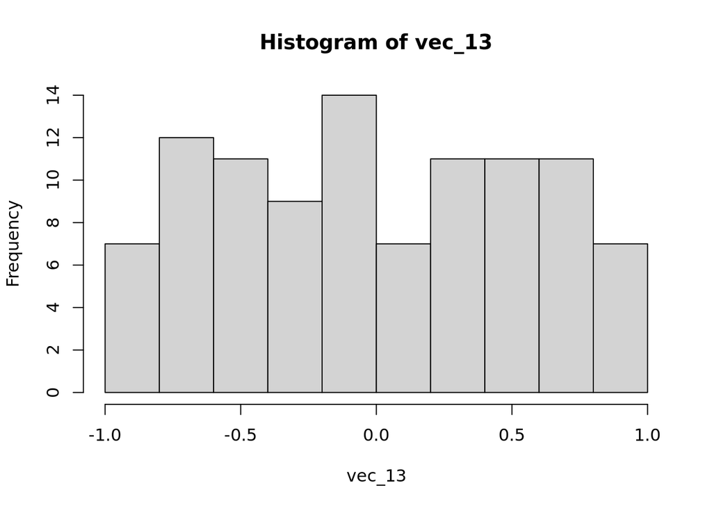

```r
hist(vec_13)
```

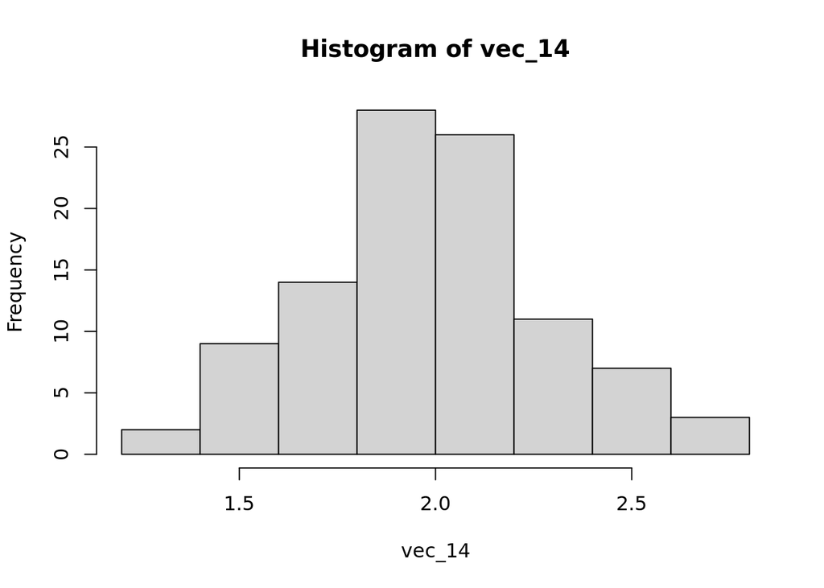

[output not shown]

```r
hist(vec_14)
```

9. Calculate the average of all values in `vec_14.` (Hint: see the function `mean()`. what did you expect to be the result? Why is the answer not exactly equal to `2`

```r
mean(vec_14)
```

```
## [1] 1.983876
```

[output not shown]

10. Now replace position `5` in vector `vec_14` with `NA`, use `vec_14[5]` in you call. Confirm your operation on this vector.

```r
vec_15 <- vec_14
vec_15[5] = NA
vec_15
```

```
##   [1] 2.075996 1.991436 1.987139 2.410581       NA 2.454941 1.535374 2.175384
##   [9] 2.037156 2.064782 2.113892 1.849303 1.900038 1.694427 1.678463 2.091059
##  [17] 2.134463 2.015901 2.276680 2.615025 1.852691 1.307249 2.301722 1.787240
##  [25] 1.793597 2.307671 1.914568 1.633785 2.054391 1.958333 2.001729 2.115584
##  [33] 1.888802 2.193313 1.933854 2.099535 2.329052 2.130554 1.902221 2.344642
##  [41] 2.298051 2.164519 2.071620 1.811628 2.408196 1.819922 2.656200 2.459783
##  [49] 1.929290 1.692074 1.786878 2.077065 1.925992 1.895737 1.714514 1.986492
##  [57] 1.764529 1.499617 1.885932 2.275699 1.827396 2.182389 1.514635 1.983331
##  [65] 2.155822 2.090346 2.031703 1.807788 1.745089 1.692761 2.035294 1.715758
##  [73] 1.852833 1.923172 2.553159 1.804415 2.070616 2.023388 1.711443 1.978608
##  [81] 2.433365 2.135451 2.012370 1.873251 1.384026 2.339401 1.561808 2.221984
##  [89] 2.572731 1.566832 2.210535 1.921341 1.528357 1.545600 1.519539 1.840728
##  [97] 1.561473 2.206375 2.630033 1.613891
```

11. Calculate the mean of `vec_14` again. (Hint: make sure you deal with the missing values!). Look at `?mean()` for the solution.

```r
mean(vec_15, na.rm = TRUE)
```

```
## [1] 1.984397
```

# 4. Vector indices

1. Pull out all values that round down to 1.0 in vector `vec_1` *HINT use `as.integer()` than create a logical index, then use the logical index to get to your answer*

```r
round_to_one <- round(vec_1, digits = 0) == 1
round_to_one
```

```
##  [1] FALSE FALSE FALSE FALSE FALSE FALSE FALSE FALSE FALSE FALSE
```

```r
vec_1[round_to_one]
```

```
## numeric(0)
```

```r
round(vec_1, digits = 0)
```

```
##  [1] -1  0  2  0  0  2  0 -1 -1  0
```

```
+ Actually rounding doesn't yield any results as your can see. But when we use `as.integer`, then sure.
```

```r
as_int <- as.integer(vec_1) == 1
as_int
```

```
##  [1] FALSE FALSE  TRUE FALSE FALSE  TRUE FALSE FALSE FALSE FALSE
```

```r
vec_1[as_int]
```

```
## [1] 1.558708 1.715065
```

# 5. The Matrix

1. Create a matrix (matrix_1) of four columns and three rows with increasing integers from 1 to 12, left to right and then top to bottom. Use the function matrix(). See the help first.

```r
matrix_data <- c(1:12)
matrix_1 <- matrix(matrix_data, 3, 4, byrow = TRUE)
matrix_1
```

```
##      [,1] [,2] [,3] [,4]
## [1,]    1    2    3    4
## [2,]    5    6    7    8
## [3,]    9   10   11   12
```

2. Create a matrix (matrix_2) of four columns and three rows, the first column only containing the value 1, the second only 2, the third only 3 and the fourth column only 4.

```r
matrix_2_data <- c(1:4)
matrix_2 <- matrix(matrix_2_data, 3, 4, byrow = TRUE)
matrix_2
```

```
##      [,1] [,2] [,3] [,4]
## [1,]    1    2    3    4
## [2,]    1    2    3    4
## [3,]    1    2    3    4
```

3. Calculate the sum of matrix_1. (Hint: see the function sum())

```r
sum(matrix_1)
```

```
## [1] 78
```

# 6. From vectors to tibbles

1. A numerical vector named `numbers` consisting of the following numbers: `1.8, 4.5, 10.1, 8.3`.

```r
numbers <- c(1.8, 4.5, 10.1, 8.3)
numbers
```

```
## [1]  1.8  4.5 10.1  8.3
```

2. A numerical vector named `prime` consisting of the following integers: `1, 3, 5, 7` and `11`

```r
prime <- c(1, 3, 5, 7, 11)
prime
```

```
## [1]  1  3  5  7 11
```

3. A character vector named `crazy` consisting of the following values: `‘abc1’, ‘foo2’, ‘bar3’, ‘app5’`and`‘yepp7’`

```r
crazy <- c("abc1", "foo2", "bar3", "app5", "yepp7")
crazy
```

```
## [1] "abc1"  "foo2"  "bar3"  "app5"  "yepp7"
```

4. A logical vector named `valid` consisting of: `TRUE, FALSE, FALSE, TRUE` and `FALSE`

```r
valid <- c(TRUE, FALSE, FALSE, TRUE, FALSE)
valid
```

```
## [1]  TRUE FALSE FALSE  TRUE FALSE
```

5. Try to create a list called `mylist` containing the vectors numbers, prime, crazy and valid.

```r
mylist <- c(numbers, prime, crazy, valid)
mylist
```

```
##  [1] "1.8"   "4.5"   "10.1"  "8.3"   "1"     "3"     "5"     "7"     "11"
## [10] "abc1"  "foo2"  "bar3"  "app5"  "yepp7" "TRUE"  "FALSE" "FALSE" "TRUE"
## [19] "FALSE"
```

6. Try to create a tibble named `mydata` with the function `tibble()` from the above four vectors. This will fail, why? .

```r
mydata <- tibble(numbers, prime, crazy, valid)
```

```
## Error: Tibble columns must have compatible sizes.
## * Size 4: Existing data.
## * Size 5: Column at position 2.
## ℹ Only values of size one are recycled.
```

```r
mydata
```

```
## Error in eval(expr, envir, enclos): object 'mydata' not found
```

```
+ It fails because it doesn't have the same amount of values in each vector.
```

7. Fix the error you found by creating an extra `NA` value in one of the vectors. Create the dataframe. Also try giving the columns different names. (Hint: see the function `names()` and the function `tibble()`.

```r
mydata_fixed <- tibble(c(numbers, NA), prime, crazy, valid)
names(mydata_fixed) <- c("numbers", "prime", "crazy", "valid")
mydata_fixed
```

```
## # A tibble: 5 x 4
##   numbers prime crazy valid
##     <dbl> <dbl> <chr> <lgl>
## 1     1.8     1 abc1  TRUE
## 2     4.5     3 foo2  FALSE
## 3    10.1     5 bar3  FALSE
## 4     8.3     7 app5  TRUE
## 5    NA      11 yepp7 FALSE
```

8. What happens if you try to calculate the sum of `mydata`?

```r
sum(mydata_fixed)
```

```
## Error in FUN(X[[i]], ...): only defined on a data frame with all numeric variables
```

```
+ Error, they're not all numbers.
```

9. When you look at the structure of the tibble using `str()`, you will see that the crazy column with the `“abc1”, “foo2”`, etc values has a certain data type. Which data type is “`name`”? Do you think it is the right type? Or do you need to change it? To what other type could you change it?

```r
str(mydata_fixed)
```

```
## tibble [5 × 4] (S3: tbl_df/tbl/data.frame)
##  $ numbers: num [1:5] 1.8 4.5 10.1 8.3 NA
##  $ prime  : num [1:5] 1 3 5 7 11
##  $ crazy  : chr [1:5] "abc1" "foo2" "bar3" "app5" ...
##  $ valid  : logi [1:5] TRUE FALSE FALSE TRUE FALSE
```

```
+ I'm not so sure what the question is for this?
```